# **Pesquisa PV - Decisões**

## Metodologia de coleta dos dados

O presente estudo foi realizado buscando dados do Portal de Informações Gerenciais (PIG) em 27/08/2021. Este sistema é o SAP BusinessObjects BI (SAP BO) que é um conjunto centralizado de ferramentas de relatórios e análises para plataformas de business intelligence (BI). Ele consiste em uma série de aplicativos de relatórios que permitem aos usuários descobrir dados, realizar análises para obter insights e criar relatórios que visualizam os insights.

Este sistema faz registro de diversas dimensões de dados do STF, desde recebimento do processo no STF até sua baixa. Para o presente estudo foram extraídos dados de decisão de 2006 até 31.06.2021.

Foram realizadas algumas correções nos dados extraídos com a finalidade de dar maior consistência e permitir que o estudo traga informações valiosas. Especificamente, foi realizado correção na variável `órgão julgador`, que registra o responsável pela decisão seja ministro ou órgão colegiado. Havia cerca de 35 mil processos cadastrados erroneamente como **presenciais** quando na verdade eram **virtual**.

Embora os dados sejam de 2006 até 2021, para responder às perguntas levantadas pela Secretaria de Altos Estudos (SAE) serão realizados recortes temporais necessários em cada questionamento suscitado.

## Dicionário dos dados

- **classe**: classe processual
- **numero**: número associado a classe processual acima
- **link**: composição entre classe processual e seu número, criando uma chave única para cada processo.
- **meio_processo**variável que verifica se é um processo físico ou eletrônico.
- **data_autuacao**: data em que o processo foi autuado (entrou) no STF.
- **data_baixa**: data em que o processo foi baixado no STF, isto é, é um processo que não faz parte mais do rol de processos em tramitação do Tribunal.
- relator_atual: é variável que registra o relator atual do processo. Caso o processo já tenha sido baixado, o relator atual será o último ministro que tenha ficado como relator do processo, que pode ser diferente do nome_ministro abaixo.
- **nome_ministro_a**: variável que registra o ministro responsável pela decisão. Quando o relator submete ao plenário e vence, seu nome é registrado nessa variável. Quando o relator é vencido, então é utilizado o primeiro ministro a discordar do relator como referência para decisão.
- **ano_andamento**: ano da decisão.
- **mes_andamento** mês da decisão.
- **data_andamento**: data da decisão.
- **andamento**: variável que registra o andamento de decisão associada ao processo.
- **observacao_andamento**: campo livre que permite inclusão de informações adicionais sobre a decisão do processo. É uma variável rica para exploração.
- **subgrupo_andamento_comissao**: variável que registra o grupo que o andamento de decisão pertence, por exemplo, se é uma decisão do grupo liminar, se é uma decisão do grupo final, e assim por diante.
- **primeira_decisao_final**: andamento da primeira decisão final.
- **data_primeira_decisao_final**: data da primeira decisão final.
- **primeira_decisao_liminar**: andamento da primeira decisão liminar.
- **data_primeira_decisao_liminar**: data da primeira decisão liminar.
- **orgao_julgador**: Indica qual origem da decisão, seja ela monocrática ou colegiada;
- **tipo_decisao**: Informa se a decisão é monocrática ou colegiada;
- **ramo_direito_novo**: É classificado pelo tipo da matéria do processo que corresponde ao primeiro assunto do processo;
- **assuntos**: Informa os assuntos atribuídos ao processo;
- **preferencia_covid_19**: Informa se o processo tem algum assunto relacionado ao Covid-19;
- **indicador_virtual**: Indica se a decisão do processo foi julgada em sessões virtuais;
- **qtd_ocorrencias_processuais**: Indica a quantidade de ocorrências em um determinado andamento de um processo. Por exemplo, se um determinado processo tiver três decisões finais em um único andamento, os três serão contabilizados;

## Objetivo do estudo

O presente projeto de pesquisa objetiva analisar como o mecanismo do Plenário Virtual foi utilizado pelo Supremo Tribunal Federal durante o período de pandemia no ano de 2020, tratando-se, portanto, de uma pesquisa descritiva.

Pretende-se também proceder a uma análise comparativa em relação à maneira como o Tribunal utilizava o PV em um período anterior e como passou a utilizá-lo durante a pandemia.

## Decisões por ano e por período

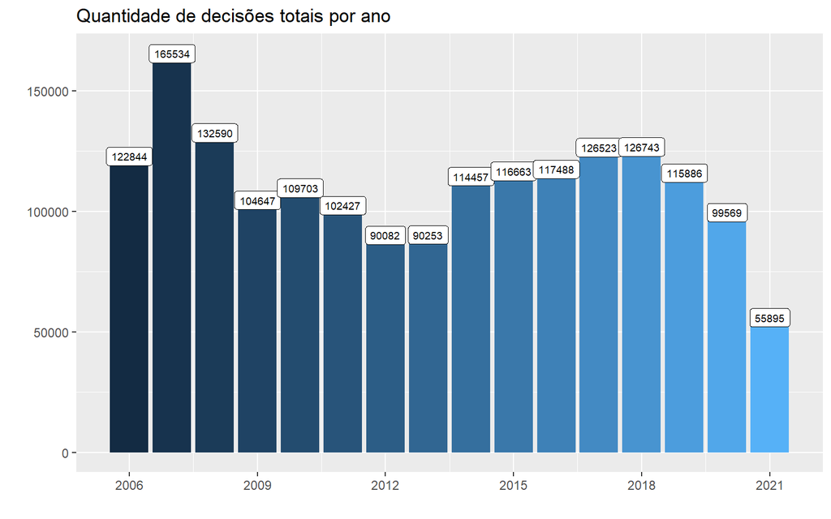

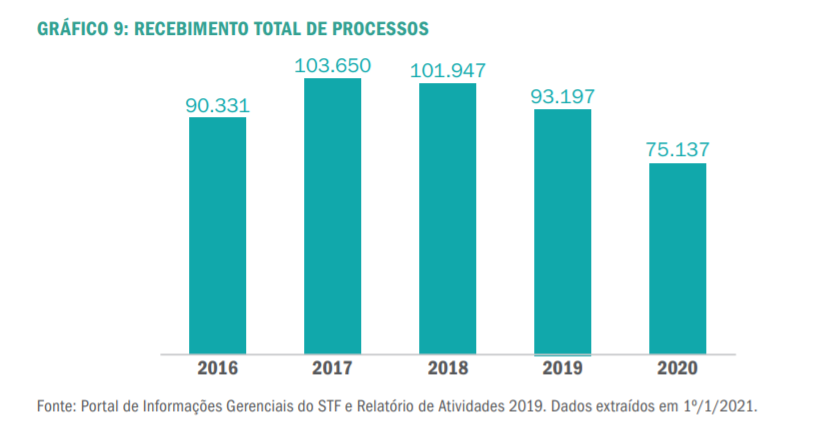

Relatório de Atividades 2020 - STF

## Decisões monocráticas e colegiadas

### Quantidade de decisões monocráticas e colegiadas no período

A base de estudo considerada dados de decisão de 2006 e observa-se que a variável tipo_decisão, que em tese deveria registrar apenas Colegiada ou Monocrática, contudo observa-se os valores `NÃO INFORMADO` e `NÃO SE APLICA`, conforme abaixo:

| tipo_decisao | n | prop |
| --- | --- | --- |
| COLEGIADA | 241752 | 13% |
| MONOCRÁTICA | 1312845 | 73% |
| NÃO INFORMADO | 235105 | 13% |
| NÃO SE APLICA | 1602 | 0% |

Há muitos casos de tipo de decisão `NÃO INFORMADO` e `NÃO SE APLICA`, observa-se que tais registros (99%) eram mais comuns nos anos de 2006 e 2007, possivelmente porque foi implementado a inclusão da informação nos sistemas do STF ainda em 2007, veja:

| ano_andamento | NÃO INFORMADO | NÃO SE APLICA | Total | prop |
| --- | --- | --- | --- | --- |
| 2006 | 111605 | 94 | 111699 | 47% |
| 2007 | 123241 | 1507 | 124748 | 53% |
| 2008 | 2 | 1 | 3 | 0% |
| 2009 | 18 | NA | 18 | 0% |
| 2010 | 3 | NA | 3 | 0% |
| 2011 | 18 | NA | 18 | 0% |
| 2012 | 216 | NA | 216 | 0% |
| 2016 | 1 | NA | 1 | 0% |
| 2018 | 1 | NA | 1 | 0% |

Retirando os `NÃO INFORMADO` e os `NÃO SE APLICA` temos que entre 2006 e meio de 2021, 16% das decisões foram colegiadas.

| tipo_decisao | n | prop |
| --- | --- | --- |
| COLEGIADA | 241752 | 16% |
| MONOCRÁTICA | 1312845 | 84% |

As decisões colegiadas e monocráticas por ano é dado abaixo:

| ano | COLEGIADA | MONOCRÁTICA |
| --- | --- | --- |
| 2006 | 11129 | 16 |
| 2007 | 23095 | 17691 |
| 2008 | 19713 | 112874 |
| 2009 | 16095 | 88534 |
| 2010 | 11342 | 98358 |
| 2011 | 13095 | 89314 |
| 2012 | 12091 | 77775 |
| 2013 | 14103 | 76150 |
| 2014 | 17074 | 97383 |
| 2015 | 17716 | 98947 |
| 2016 | 14533 | 102954 |
| 2017 | 12894 | 113629 |
| 2018 | 14529 | 112213 |
| 2019 | 17735 | 98151 |
| 2020 | 18213 | 81356 |
| 2021 | 8395 | 47500 |

Observe que o erro de registro em 2006 e 2007 deram-se principalmente nas decisões Monocráticas.Utilizamos o período temporal de 2008 adiante nas análises a seguir de forma a evitar essa questão.

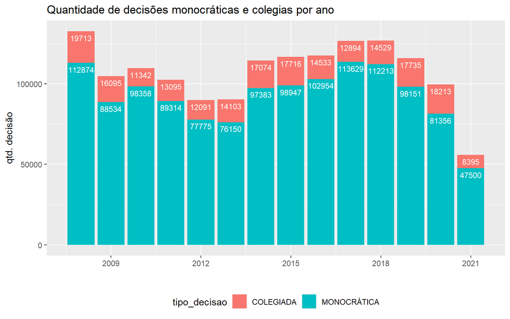

Observe que há um movimento ciclico, com momentos de fortalecimento do colegiado e outros momentos com menos força. O ano de 2020 mostrou-se como ano de reforço da do princípio da colegialidade.

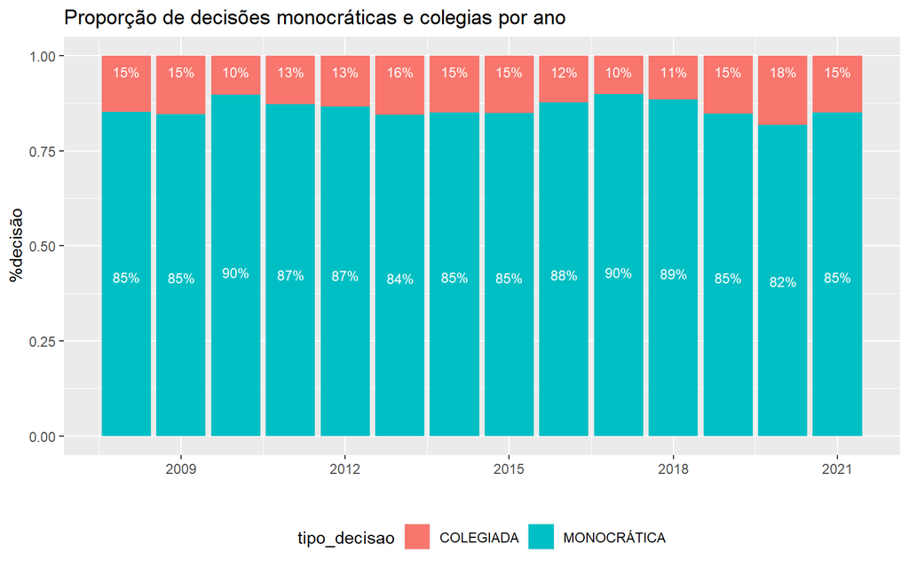

## Decisões colegiadas virtuais

O objetivo principal do estudo é análisar o ambiente virtual e compará-lo com o ambiente virtual, além de verificar os como cada orgão julgador se comportou no período. Para considerar o efeito da virtualização considerou-se aqui os dados do `Plenário Virtual da RG`, que basicamente era o ambiente virtual considerado no STF antes de 2016.

ano

presencial

virtual

perc

2008

19598

115

0.6 %

2009

16008

87

0.5 %

2010

11230

112

1 %

2011

12947

148

1.1 %

2012

11980

111

0.9 %

2013

14033

70

0.5 %

2014

16983

91

0.5 %

2015

17634

82

0.5 %

2016

9464

5069

34.9 %

2017

2747

10147

78.7 %

2018

2803

11726

80.7 %

2019

3210

14525

81.9 %

2020

813

17400

95.5 %

2021

132

8263

98.4 %

Total

139582

67946

O gráfico abaixo considera Tribunal Pleno e Turmas agregadas e faz separação apenas por decisões em ambiente virtual ou em ambiente presencial.

Observe que o movimento cíclico observado nas decisões gerais parece refletir nas decisões colegiadas também. Importante observar que há forte correlação entre as **emendas regimentais** e o aumento das decisões virtuais no Colegiado.

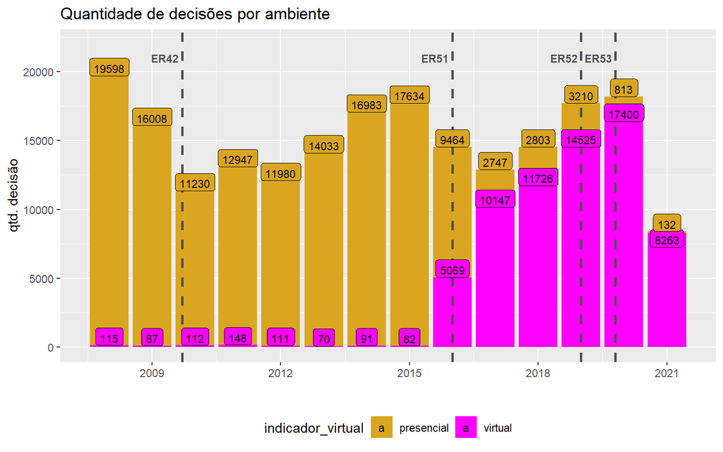

A proporção de decisões por ambiente nos mostra a participação de ambientes virtuais na corte e como essa inovação deixou de ser exceção para tornar-se regra na Corte. Observe que em 2021, menos de 2% dos processos são julgados em ambiente presencial.

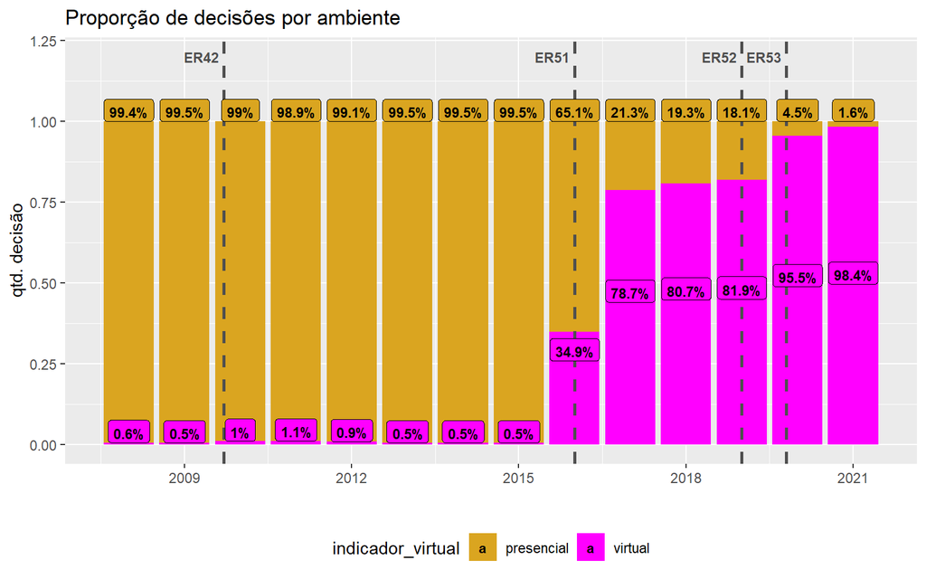

## Período Comparativo

### Período comparativo entre pré (19.6.19 a 19.3.20) e pós-pandemia (20.3.20 a 31.12.20)

Para criação dos gráficos abaixo **foram retirados** os dados do ´Plenário Virtual da RG` para comparação dos outros ambientes de decisão e simplificação gráfica.

#### Presencial x Virtual

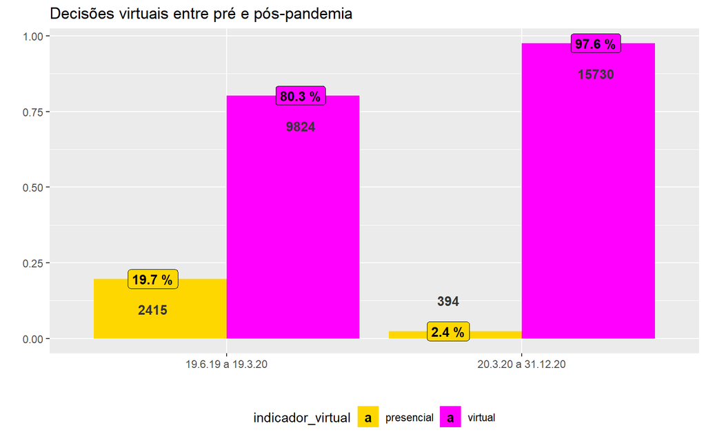

#### Comparativo entre orgãos julgadores

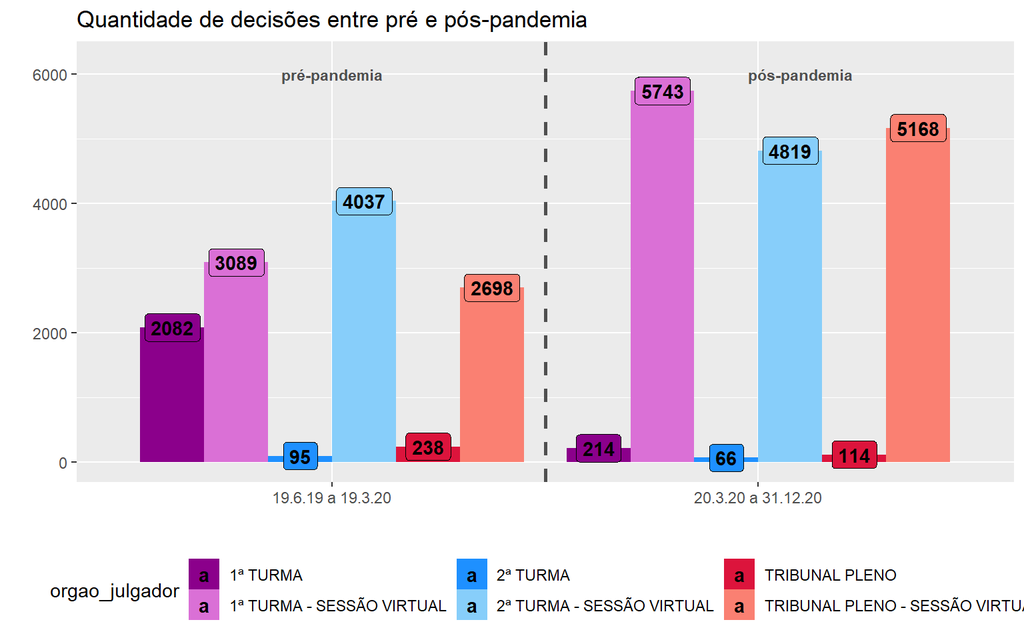

#### Proporção das decisões por orgão julgador

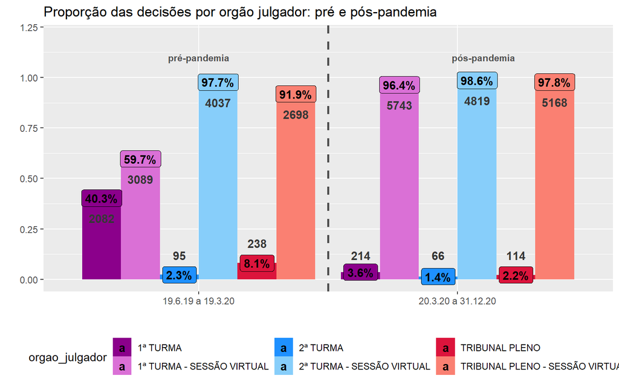

### Decisões por classe

A tabela a seguir também **não considera** os dados do `Plenário Virtual da RG`. As decisões entre os dois períodos são contabilizados somente os virtuais, excluindo-se os presenciais.

| classe | 19.6.19 a 19.3.20 | 20.3.20 a 31.12.20 |
| --- | --- | --- |
| ARE | 4940 | 5566 |
| HC | 1111 | 3443 |
| RE | 1628 | 2069 |
| Rcl | 905 | 1747 |
| RHC | 284 | 620 |
| STP | 9 | 563 |
| ADI | 274 | 490 |
| MS | 187 | 289 |
| ACO | 34 | 165 |
| RMS | 109 | 154 |
| Pet | 50 | 139 |
| ADPF | 27 | 93 |
| MI | 54 | 88 |
| AR | 52 | 70 |
| AI | 41 | 46 |
| Ext | 13 | 41 |
| SL | 23 | 35 |
| SS | 23 | 23 |
| AO | 3 | 14 |
| STA | 13 | 14 |
| AP | 6 | 10 |
| ADC | 3 | 8 |
| Inq | 9 | 8 |
| AC | 5 | 7 |
| ADO | 2 | 5 |
| AImp | 4 | 4 |
| CC | 5 | 4 |
| EP | 1 | 4 |
| RvC | 5 | 3 |
| PSV | 1 | 2 |
| TPA | NA | 2 |
| PPE | 1 | 1 |
| RHD | 1 | 1 |
| EI | NA | 1 |
| RMI | NA | 1 |
| AS | 1 | NA |
| Total | 9824 | 15730 |

## Decisões por orgão julgador

A tabela de decisões por orgão julgador **não considera** o `Plenário Virtual da RG`, como visto abaixo:

| orgao_julgador | 2008 | 2009 | 2010 | 2011 | 2012 | 2013 | 2014 | 2015 | 2016 | 2017 | 2018 | 2019 | 2020 | 2021 |
| --- | --- | --- | --- | --- | --- | --- | --- | --- | --- | --- | --- | --- | --- | --- |
| 1ª TURMA | 4669 | 6852 | 3390 | 5471 | 5775 | 5610 | 7467 | 7115 | 4252 | 2092 | 1813 | 2769 | 560 | 45 |
| 2ª TURMA | 9268 | 5829 | 5399 | 5611 | 5074 | 6047 | 6897 | 7781 | 3271 | 486 | 554 | 111 | 110 | 45 |
| TRIBUNAL PLENO | 5661 | 3327 | 2441 | 1865 | 1131 | 2376 | 2619 | 2738 | 1941 | 169 | 436 | 330 | 143 | 42 |
| TRIBUNAL PLENO - SESSÃO VIRTUAL | NA | 1 | NA | NA | NA | NA | NA | NA | 1437 | 1900 | 2806 | 3594 | 5686 | 2602 |
| 2ª TURMA - SESSÃO VIRTUAL | NA | NA | NA | 1 | NA | NA | NA | NA | 1516 | 3833 | 3598 | 6112 | 5422 | 2453 |
| 1ª TURMA - SESSÃO VIRTUAL | NA | NA | NA | NA | NA | NA | NA | NA | 2061 | 4364 | 5279 | 4769 | 6241 | 3158 |
| Total | 19598 | 16009 | 11230 | 12948 | 11980 | 14033 | 16983 | 17634 | 14478 | 12844 | 14486 | 17685 | 18162 | 8345 |

Vale lembrar que a tabela acima contabiliza tanto virtuais como presenciais. O gráfico abaixo foi construído pelo órgãos julgadores, conforme tabela a seguir:

| Orgão Julgador | Decisões |
| --- | --- |
| 1ª TURMA | COLEGIADA |
| 1ª TURMA - SESSÃO VIRTUAL | COLEGIADA |
| 2ª TURMA | COLEGIADA |
| 2ª TURMA - SESSÃO VIRTUAL | COLEGIADA |
| TRIBUNAL PLENO | COLEGIADA |
| TRIBUNAL PLENO - SESSÃO VIRTUAL | COLEGIADA |

Observe que novamente retiramos o orgão julgador `Plenário Virtual da RG`, pois comprometeria a visualização e o impacto é relativamente baixo do ponto de vista quantitativo.

As sessões presenciais e virtuais foram agregadas de forma a 1ª Turma, 2ª Turma e Tribunal Pleno, que estão separados por cores principais: roxo, azul e vermelhor. A separação virtual e presencial é pela tonalidade: escuro ou claro.

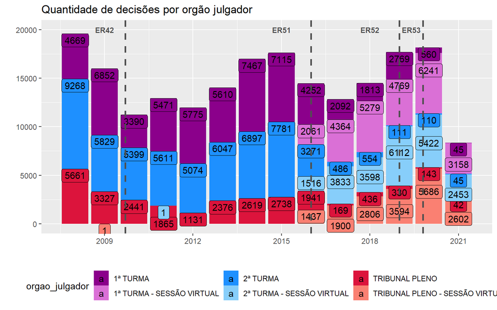

O gráfico abaixo analisa a proporção de participação dos orgãos julgadores em cada período. A participação de ambientes virtuais aumento tanto no Tribunal Pleno quanto nas turmas. Veja como há aumento das cores claras ao longo do tempo.

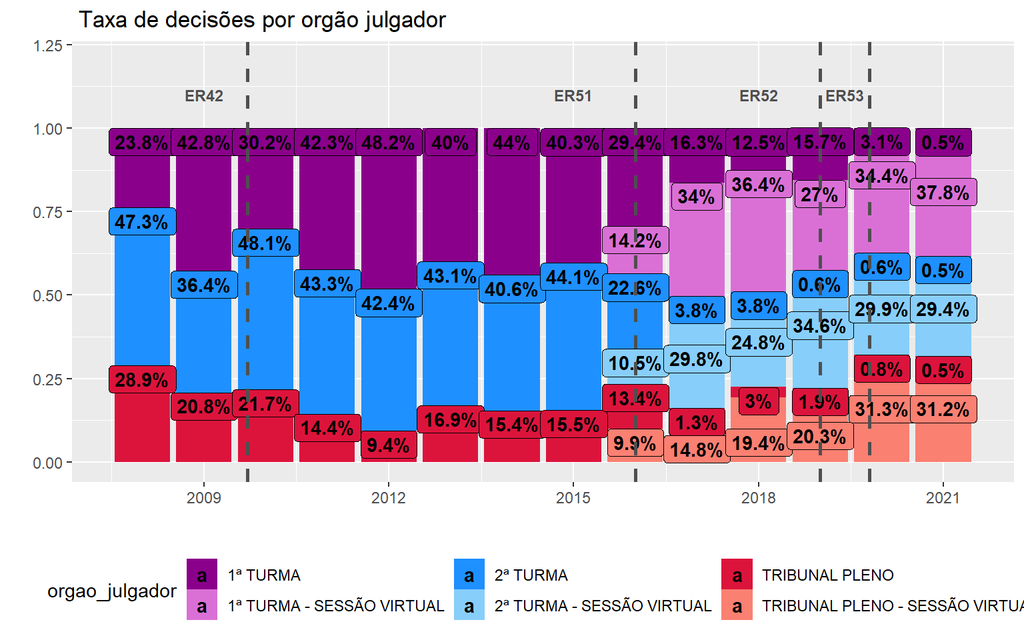

## Decisões por assunto

Os processos que chegam ao STF, em sua autuação, recebem marcador de `assunto`, que serão usados para alimentar o campo de `ramo do direito`. A partir deles serão analisados as quantidades de processos que foram decididos e analisar os marcados de assuntos nestes processos.

### Decisões por ramo do direito

| ramo_direito_novo_2 | 2016 | 2017 | 2018 | 2019 | 2020 | 2021 |
| --- | --- | --- | --- | --- | --- | --- |
| DIREITO ADMINISTRATIVO E OUTRAS MATÉRIAS DE DIREITO PÚBLICO | 1620 | 3897 | 4497 | 5604 | 4775 | 2098 |
| DIREITO PROCESSUAL PENAL | 360 | 1193 | 1808 | 2476 | 3867 | 1997 |
| DIREITO PENAL | 234 | 731 | 1075 | 1577 | 2217 | 1168 |
| DIREITO PROCESSUAL CIVIL E DO TRABALHO | 600 | 987 | 894 | 1176 | 1399 | 887 |
| DIREITO TRIBUTÁRIO | 683 | 1177 | 1269 | 1456 | 2157 | 728 |
| DIREITO DO TRABALHO | 179 | 444 | 573 | 775 | 953 | 378 |
| DIREITO CIVIL | 443 | 599 | 746 | 755 | 679 | 331 |
| QUESTÕES DE ALTA COMPLEXIDADE, GRANDE IMPACTO E REPERCUSSÃO | NA | NA | NA | NA | 518 | 320 |
| DIREITO PREVIDENCIÁRIO | 600 | 765 | 428 | 279 | 370 | 93 |
| DIREITO DO CONSUMIDOR | 206 | 184 | 240 | 180 | 141 | 61 |
| DIREITO INTERNACIONAL | 4 | 14 | 15 | 20 | 50 | 33 |
| DIREITO ELEITORAL | 37 | 47 | 74 | 77 | 66 | 32 |
| DIREITO DA SAÚDE | 1 | NA | NA | NA | 38 | 29 |
| DIREITO PROCESSUAL PENAL MILITAR | 6 | 10 | 19 | 24 | 43 | 22 |
| DIREITO PENAL MILITAR | 4 | 7 | 19 | 22 | 24 | 15 |
| DIREITO ELEITORAL E PROCESSO ELEITORAL | 5 | 16 | 9 | 18 | 21 | 8 |
| ASSUNTOS DIVERSOS | 26 | 15 | 8 | 27 | 6 | 7 |
| DIREITO DA CRIANÇA E DO ADOLESCENTE | 6 | 11 | 9 | 9 | 25 | 6 |
| Total | 5014 | 10097 | 11683 | 14475 | 17349 | 8213 |

Observe que o ramo do direito `questões de alta complexidade, grande impacto e repercussão` passou a ser registrado a partir de 30/03/2020, por isso só há registro no período pós-pandemia.

A tabela abaixo verifica quais foram os ramos do direito mais decididos durante o período pré e pós pandemia.

### Ramo do Direito no período pré e pós pandemia

| ramo_direito_novo_2 | 19.6.19 a 19.3.20 | 20.3.20 a 31.12.20 |
| --- | --- | --- |
| DIREITO ADMINISTRATIVO E OUTRAS MATÉRIAS DE DIREITO PÚBLICO | 3539 | 4248 |
| DIREITO PROCESSUAL PENAL | 1776 | 3544 |
| DIREITO PENAL | 1118 | 2030 |
| DIREITO TRIBUTÁRIO | 1082 | 1986 |
| DIREITO PROCESSUAL CIVIL E DO TRABALHO | 838 | 1237 |
| DIREITO DO TRABALHO | 509 | 874 |
| DIREITO CIVIL | 521 | 586 |
| QUESTÕES DE ALTA COMPLEXIDADE, GRANDE IMPACTO E REPERCUSSÃO | NA | 518 |
| DIREITO PREVIDENCIÁRIO | 176 | 338 |
| DIREITO DO CONSUMIDOR | 108 | 123 |
| DIREITO ELEITORAL | 54 | 61 |
| DIREITO INTERNACIONAL | 18 | 47 |
| DIREITO PROCESSUAL PENAL MILITAR | 24 | 36 |
| DIREITO DA SAÚDE | 4 | 34 |
| DIREITO DA CRIANÇA E DO ADOLESCENTE | 7 | 24 |
| DIREITO PENAL MILITAR | 13 | 22 |
| DIREITO ELEITORAL E PROCESSO ELEITORAL | 15 | 19 |
| ASSUNTOS DIVERSOS | 22 | 3 |
| Total | 9824 | 15730 |

Assim, foi criada a tabela de frequência de principais assuntos com os 100 assuntos de maior frequência no período considerado.

### Top 100 assuntos no período pré (19.6.19 a 19.3.20) e pós-pandemia (20.3.20 a 31.12.20).

Essa também, mantendo consistência com outras tabelas, não considera os dados do orgão julgador `Plenário Virtual da RG`.

| ano_andamento | ramo_direito_novo_2 | assuntos | qtd |
| --- | --- | --- | --- |
| 2020 | DIREITO TRIBUTÁRIO | 1 - DIREITO TRIBUTÁRIO \| CONTRIBUIÇÕES \| CONTRIBUIÇÕES ESPECIAIS \| FUNDEF/FUNDO DE MANUTENÇÃO E DESENVOL | 463 |
| 2020 | DIREITO ADMINISTRATIVO E OUTRAS MATÉRIAS DE DIREITO PÚBLICO | 1 - DIREITO ADMINISTRATIVO E OUTRAS MATÉRIAS DE DIREITO PÚBLICO \| SERVIDOR PÚBLICO CIVIL \| SISTEMA REMUN | 450 |
| 2020 | DIREITO PENAL | 1 - DIREITO PENAL \| PARTE GERAL \| APLICAÇÃO DA PENA | 444 |
| 2020 | DIREITO PROCESSUAL PENAL | 1 - DIREITO PROCESSUAL PENAL \| PRISÃO PREVENTIVA \| REVOGAÇÃO | 359 |
| 2019 | DIREITO ADMINISTRATIVO E OUTRAS MATÉRIAS DE DIREITO PÚBLICO | 1 - DIREITO ADMINISTRATIVO E OUTRAS MATÉRIAS DE DIREITO PÚBLICO \| SERVIDOR PÚBLICO CIVIL \| SISTEMA REMUN | 290 |
| 2020 | DIREITO PROCESSUAL PENAL | 1 - DIREITO PROCESSUAL PENAL \| LIBERDADE PROVISÓRIA | 261 |
| 2020 | DIREITO ADMINISTRATIVO E OUTRAS MATÉRIAS DE DIREITO PÚBLICO | 1 - DIREITO ADMINISTRATIVO E OUTRAS MATÉRIAS DE DIREITO PÚBLICO \| SERVIDOR PÚBLICO CIVIL \| REGIME ESTATU | 220 |
| 2020 | DIREITO PROCESSUAL PENAL | 1 - DIREITO PROCESSUAL PENAL \| AÇÃO PENAL \| NULIDADE | 216 |
| 2020 | DIREITO PENAL | 1 - DIREITO PENAL \| PARTE GERAL \| APLICAÇÃO DA PENA \| REGIME INICIAL | 183 |
| 2020 | DIREITO PROCESSUAL PENAL | 1 - DIREITO PROCESSUAL PENAL \| AÇÃO PENAL \| NULIDADE \| CERCEAMENTO DE DEFESA | 183 |

[output cut: 93 more lines]

Nas pesquisas por assunto e ramo do direito foram realizados contabilizando apenas as decisões virtuais.

FIM